# Introduction to KNN classification

Author

Dr. Niloufar Abourashchi and Dr. Thomas Honnor

## Workshop Agenda

- Review ways to summarise and visualise data
- Look at an example of a classification problem and the K-nearest neighbours (KNN) algorithm
- Discuss the central limit theorem

### Today’s Tasks

1- Group work on summary statistics and visualising data

2- Classification using the KNN algorithm

3- Central limit theorem, hypothesis testing and t-tests

## Summary Statistics and Visualising Data

- Databases are typically large!
- We need ways to summarise or illustrate key features of the database
- Such data summaries might take the form of…
  - **quantities**: mean / sd / range /min / max
  - **plots**: barcharts, boxplots,histograms,scatterplots
- **To compare** between data groups we might make comparison tables, overlaid plots, or multiplot figures.

## Palmer Penguins

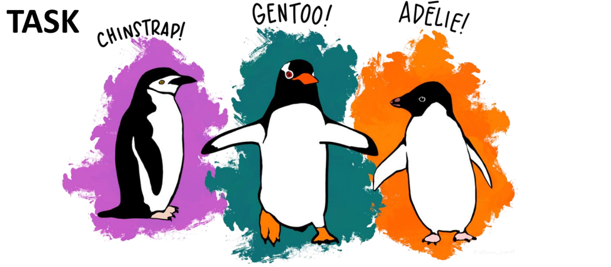

## Key details

- The Palmer penguins database includes body measurements from three different species of penguin from three islands in Antarctica
- The database is provided as an R package.
- You can download the database using: `install.packages("palmerpenguins")`
- You can then load in the package into your R work-space using:`library(palmerpenguins)`
- And view the data using: `head(penguins)`

### The variables

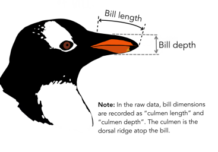

- The variables stored for the penguins are:
- species
- island
- bill_length_mm
- bill_depth_mm
- flipper_length_mm
- body_mass_g
- sex
- year

**Your turn!**

#### Group Assignment: Completing the R Notebook for Data Summarization

- **Instructions:**
- Work in groups to complete the template R Notebook [Data Summarization task](https://moodle.ucl.ac.uk/pluginfile.php/7179692/mod_resource/content/1/2%20-%20Summarising%20Data.Rmd). This task involves using R to produce summary statistics and plots.
- Add example code and appropriate comments for each heading provided in the Data Summarization task.
- Comments should explain when a statistic or plot is a good or bad choice.
- Choose examples that highlight the features of the Palmer Penguins dataset, allowing us to compare differences such as those between penguin species and gender.
- **Objective:**
- In this notebook, you will load the Palmer Penguins dataset and demonstrate how to use R for generating summary statistics and visualizations. Your goal is to elucidate the key features of the dataset and the distinctions between penguin species.
- **Steps:**
- Install the Necessary Package:
- To access the data, you need to install the palmerpenguins package. This is done by running `install.packages("palmerpenguins")` in the R console window. Note that this command is not included in the Notebook as it only needs to be executed once.

*Load the Data:*

- Use the appropriate R commands to load and explore the dataset.
- *Generate Summary Statistics:*
  - Provide code examples and comments for generating summary statistics such as mean, median, standard deviation, and others. Explain the suitability of each statistic for different types of data analysis.
- *Create Visualizations:*
  - Include example code and comments for creating plots such as histograms, boxplots, scatter plots, and more. Discuss when each type of plot is most useful and what insights it can provide.

**Resources:**

**Resources:**

- You can refer to the complete model solution for this task [here](https://moodle.ucl.ac.uk/pluginfile.php/7179694/mod_resource/content/1/2c%20-%20Summarising%20Data.html).

## Introduction to KNN classification

Let’s consider an experiment monitoring dragonflies in a certain environment.

When a dragonflies lands on the sensor a picture is taken and its mass and wingspan are recorded.

Experts can determine the species (either A or B) from the camera image, but we want to code an algorithm that uses the mass and wingspan information to predict species without a human needing to check the photo.

> This is an example of a *classification problem**.*

We suppose we start with a set of dragonfly observations that have their species labelled by an expert from the photographs. This can be found in file `dragonfly.csv`.

This is called the *training* data because we will use it as the input to “train” our classification algorithm.

We are then given another file `dragonfly2.csv` containing a dataset in which the species labels have not been included. Our task is to try to classify them as species A or species B.

Let’s start by loading and viewing the data:

```r
library(tidyverse)
```

```r
dragonfly <- read_csv("dragonfly.csv")
```

This contains columns `id` storing row number, `mass` storing mass in grams, `wspan` containing wingspan in cm, and `species` which is set to either “A” or “B”. In this case species is a factor type category, so we convert this:

```r
dragonfly <- mutate(dragonfly, species=factor(species))
```

Let’s plot the data using `geom_point` colouring the points by species:

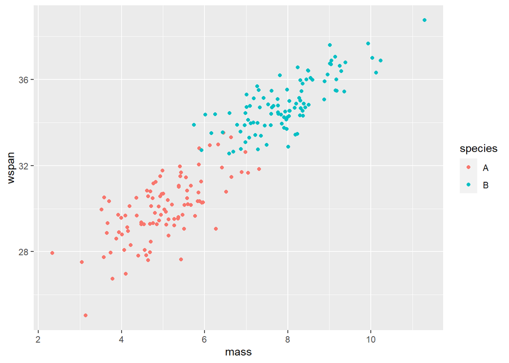

```r
ggplot(data = dragonfly,
       mapping=aes(y=wspan,
                   x=mass,
                   color=species)) +
  geom_point()
```

We can see that:

- there is a general trend, with larger mass meaning larger wingspan
- species A tends to have smaller wingspan and mass
- species B tends to have larger wingspan and mass
- the larger species A dragonflies are similar in size to smaller species B dragonflies.

Let’s load in the second datafile. We’ll call it the *test* data because we will use it to test our classification method:

```r
dragonfly2 <- read_csv("dragonfly2.csv")
```

We can use ggplot to plot both datasets, by specifying the data in the `geom_point()` command:

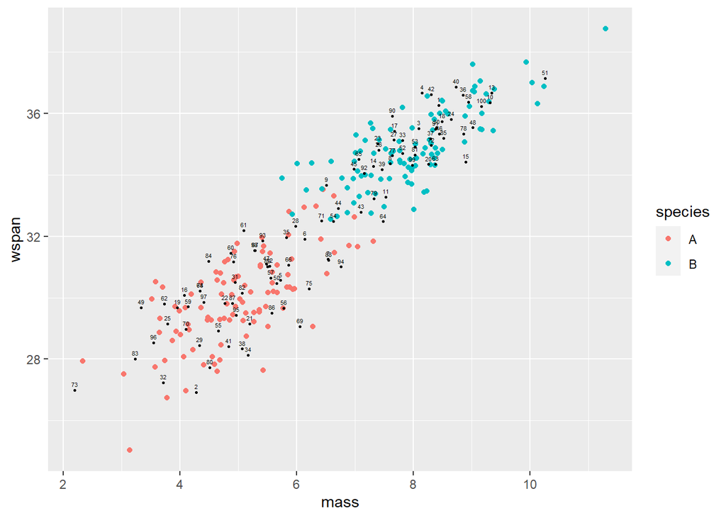

```r
ggplot() +
  geom_point(data = dragonfly,
             mapping=aes(y=wspan,
                         x=mass,
                         color=species)) +
  geom_point(data = dragonfly2,
             mapping=aes(y=wspan,
                         x=mass),
             colour="black", size=0.5) +
  geom_text(data = dragonfly2,              # adds text labels from id column
            mapping=aes(y=wspan,
                        x=mass,
                        label=id),
            size=1.5,                       # adjusts text size
            nudge_y=.2)                     # nudges text up to avoid overlapping
```

In this case we see that the measurements from species A and species B are clustered in different regions of the plot, and by judging which cluster the unknown dragonflies belong to we could manually assign species. This is easy for points that lie clearly in one cluster, but the classification is less clear when the unknown point is in a region where the clusters are overlapping.

In this case we might make a decision by looking at which point in the training data is closest to our unknown point. This “closest neighbour” is the one with most similar characteristics (in this case in terms of wingspan and mass) and we then make our prediction based on the species of our point’s neighbour.

One issue with this method is that due to the random variation of the dragonflies we might have a case such as an unusually small dragonfly of species B, which falls in a region more commonly associated with species A. (e.g. see the blue point near unknown point 28).

If our unknown point was closest to such a point the closest neighbour method would predict it as species B, even though in nearby region its neighbours are more commonly of species A.

The K-nearest neighbours (KNN) algorithm is a simple way to approach this problem. In this case the value of $K$ represents the number of neighbours used when comparing the unknown point to the training set. For example, using the method with $K=5$ means we would use the nearest 5 neighbours to make our prediction.

The optimal value of $K$ to use will differ in different contexts and depending on the size of the training dataset, and distributions of each cluster.

We then use the characteristics of the neighbours to make our predcition. In this case where we are predicting the species, we would predict the unknown species to be in line with the majority of its neighbours.

For example if from the 5 nearest neighbours: 1 was of species A, and 4 were of species B; then our species prediction would be B.

# Normalising the data

In order to calculate the nearest neighbour we need some way of fairly measuring the “distance” between two entries based on the set of predictors we have. Because predictors can take different units and scales we can’t just add the distances (or e.g. the squares of the distances) to do this.

We need to normalise the variables so that they are on comparable scales. There are a couple of methods to do this, we can look at the minimum and maximum values for a variable then map all the values to e.g the range 0 to 1, or we can centre the values by subtracting the means, then normalise the distribution width by dividing by the standard deviation.

In order to normalise all the data (from files dragonfly.csv and dragonfly2.csv) it is useful to combine them into a single dataframe. This ensures the same scaling is applied to all the data:

```r
# create species column in dragonfly2 with NA entries
dragonfly2$species <- NA

dragonfly_all <- bind_rows(dragonfly, dragonfly2)
```

Example R code for normalisation is then:

```r
# to mutate a set of columns we can use the mutate_at() function
# and pass the column names we want it to operate on

dragonfly_all_norm <- dragonfly_all %>%
  mutate_at(c("mass","wspan"),scale)

# after applying the same scaling to all the data we can split it back
# into the original groups

dragonfly_norm <- dragonfly_all_norm %>%
  filter(is.na(species) == FALSE)

dragonfly2_norm <- dragonfly_all_norm %>%
  filter(is.na(species) == TRUE)
```

# Using the `knn()` function

The `knn()` function in R is ready-made to carry out the K-nearest neighbours prediction.

In this case:

- our input values to use when calculating nearest neighbours are columns `wspan` and `mass`.
- our output variable we want to predict is the column `species`.

To use the function we need to create:

- dataframe `X_train` stores input variables columns of training dataset
- vector `Y_train` stores output variable of training dataset
- dataframe `X_test` stores input variables columns of test dataset

and we will store the output of the function in:

- dataframe `Y_test_predicted` which will store the predicted output variable for our test dataset

Lets prepare the input for the function. In this case the labelled `dragonfly_norm` data frame contains our training dataset, and the unlabelled `dragonfly2_norm` data frame contains our test dataset that we want to make predictions for.

```r
df_train <- dragonfly_norm
df_test <- dragonfly2_norm
```

```r
X_train <- select(df_train, wspan, mass)
Y_train <- df_train$species

# Note here we can't use Y_train <- select(df_train, species)
# because the select() function returns a data.frame with one column
# and knn() expects a vector not a dataframe

X_test <- select(df_test, wspan, mass)
```

Now we can apply the method using `k=5` so that we look at the nearest 5 neighbours:

```r
library(class)

Y_test_predicted <- knn(X_train, X_test, Y_train, k=5)
```

Let’s put the prediction back into our dragonfly dataframe:

```r
df_test$species_predicted <- Y_test_predicted
```

We can now check our method by plotting the results. Here we make the training points more transparent using the alpha argument (`0` is fully transparent, `1` is fully solid), and change marker style to highlight our predicted species data.

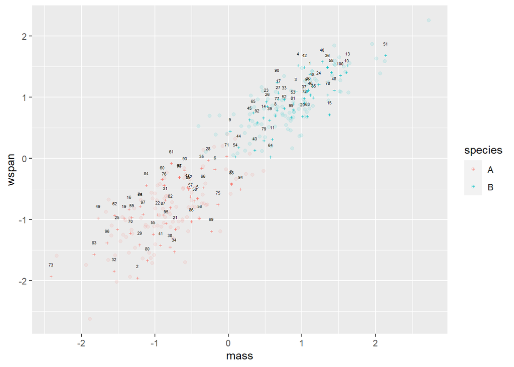

```r
ggplot() +
  geom_point(data = df_train,
             mapping=aes(y=wspan,
                         x=mass,
                         color=species),
             alpha=0.1) +                 # alpha sets these to be transparent
  geom_point(data = df_test,
             mapping=aes(y=wspan,
                         x=mass,
                         color=species_predicted),
             shape=3, size=0.5) +
  geom_text(data = df_test,
            mapping=aes(y=wspan,
                        x=mass,
                        label=id),
            size=1.5,
            nudge_y=.2)
```

In this case we do actually have access to the species for the test data. These are available in the `dragonfly2_labels.csv` file.

```r
df_test_labels <- read_csv("dragonfly2_labels.csv")
```

The correct species values are in column species_actual and in the same order as the dragonflies2.csv file. We convert this to a factor and add the information as a new column in our df_test dataframe.

```r
df_test$species_actual <- factor(df_test_labels$species_actual)

head(df_test)
```

```
# A tibble: 6 × 6
     id mass[,1] wspan[,1] species species_predicted species_actual
  <dbl>    <dbl>     <dbl> <fct>   <fct>             <fct>
1     1    1.11      1.37  <NA>    B                 B
2     2   -1.24     -1.96  <NA>    A                 A
3     3    0.917     1.10  <NA>    B                 B
4     4    0.947     1.51  <NA>    B                 B
5     5   -0.420    -0.660 <NA>    A                 A
6     6   -0.184    -0.183 <NA>    A                 A
```

We can see now `df_test` contains columns with the predicted and actual species.

A useful way to view the results is using table to show the confusion table summarising how the predictions compared to the actual results:

```r
table(df_test$species_actual,
      df_test$species_predicted)
```

```
     A  B
  A 51  2
  B  1 46
```

To help us to read the table its useful to label the table:

```r
table(actual = df_test$species_actual,
      predicted = df_test$species_predicted)
```

```
      predicted
actual  A  B
     A 51  2
     B  1 46
```

We can now more easily see how the predictions and actual values compare. Here the diagonal elements are the correctly predicted species. In this case we:

- predicted 51 as species A which were actually A
- predicted 46 as species B which were actually B

The off diagonal elements are counts of wrong predictions. In this case we:

- predicted 1 as species A which were actually B
- predicted 2 as species B which were actually A

One way to measure the performance of a classification algorithm is to calculate its accuracy – the percantage of correct predictions. In this case we can use `R` to compare the predicted and actual columns:

```r
n_correct <- sum(df_test$species_actual == df_test$species_predicted)
n_incorrect <- sum(df_test$species_actual != df_test$species_predicted)

# how these work:
# df_test$species_actual == df_test$species_predicted
# produces vector of TRUE / FALSE values which
# stores TRUE where prediction matched values / FALSE otherwise
# sum() function acts to count number of TRUE entries in a vector
# as treats TRUE as having value 1 and FALSE having value 0

n_total <- n_correct + n_incorrect

accuracy <- n_correct / n_total
accuracy
```

```
[1] 0.97
```

In this case our method had an accuracy of 0.97 or 97%.

**Exercise: KNN penguin data**

Use the KNN method with `k=5` to predict the species of the unknown penguins using input variables flipper_length_mm and mass_g and the penguins with known species as the training dataset.

Workflow:

- load file `penguins_knn.csv` this has an extra column species_actual containing all species which we can use to check the results.
- normalise the columns used for prediction species (`flipper length`, `body mass`, `bill length`, `bill depth`)
- construct dataframes `penguin_train` and `penguin_test`
- use ggplot to make a plot showing a `geom_point` scatter plot for the training data, colouring the points by species.
- modify the plot to include the points from the test dataset.
- by referring to the example code above, construct `X_train`, `Y_train`, and `X_test`
- use the `knn()` function to create predictions setting $K$ to 5 and store the output as `Y_test`
- write the predictions `Y_test` into the penguin test dataframe as `species_predicted`
- create a confusion table to display the results. Check you can interpret it by answering the following questions:
  - How many penguins in the test dataset were predicted as Adelie?
  - How many penguins in the test dataset were actually Adelie?
  - How many penguins in the test dataset were correctly predicted Gentoo?
  - How many penguins in the test dataset were incorrectly predicted Gentoo?
  - How many penguins in the test dataset were actually Chinstrap but predicted to be Adelie?
- calculate the number of correct predictions, and the overall accuracy.

## Extension

- Repeat the `knn()` analysis with $K$=5 but including the `bill_depth_mm` and `bill_length_mm` as input variables. Does this increase the accuracy of the method?
- Edit your code to test how the accuracy changes when $K$ takes values: 1, 5, 10, 15, 25, 50.
- Which $K$ value results in the highest accuracy in this case?

**Solution**

```r
library(tidyverse)
library(class)
```

```r
penguin <- read_csv("penguins_knn.csv", col_types="dfddddfdf")
names(penguin)
```

```
[1] "id"                "species"           "bill_length_mm"
[4] "bill_depth_mm"     "flipper_length_mm" "body_mass_g"
[7] "sex"               "year"              "species_actual"
```

```r
 #to mutate a set of columns we can use the mutate_at() function
# and pass the column names we want it to operate on

penguin_norm <- penguin %>%
mutate_at(c("bill_length_mm",
"bill_depth_mm",
"flipper_length_mm",
"body_mass_g"),scale)
```

- construct dataframes penguin_train and penguin_test

```r
penguin_train <- filter(penguin_norm, !is.na(species) )
penguin_test <- filter(penguin_norm, is.na(species) )
# check counts add up!
nrow(penguin)
```

```
[1] 344
```

```r
nrow(penguin_test)
```

```
[1] 50
```

```r
nrow(penguin_train)
```

```
[1] 294
```

```r
# drop_na function allows us to drop
# any rows with NA values
# from the training set
penguin_train <- drop_na(penguin_train)
nrow(penguin_train)
```

```
[1] 284
```

- use ggplot to make a plot showing a geom_point scatter plot for the training data, colouring the points by species

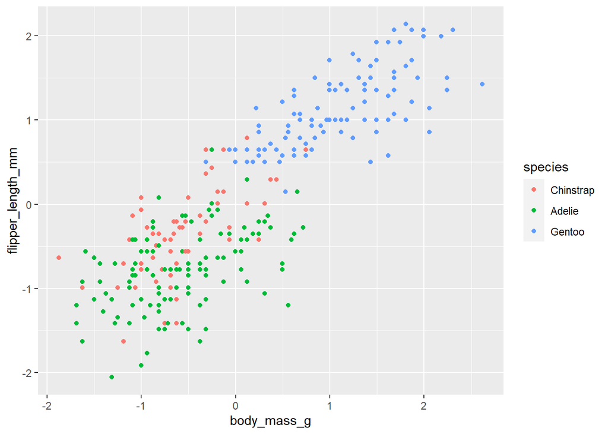

```r
ggplot(data=penguin_train,
mapping=aes(x=body_mass_g, y=flipper_length_mm, color=species) ) +
geom_point()
```

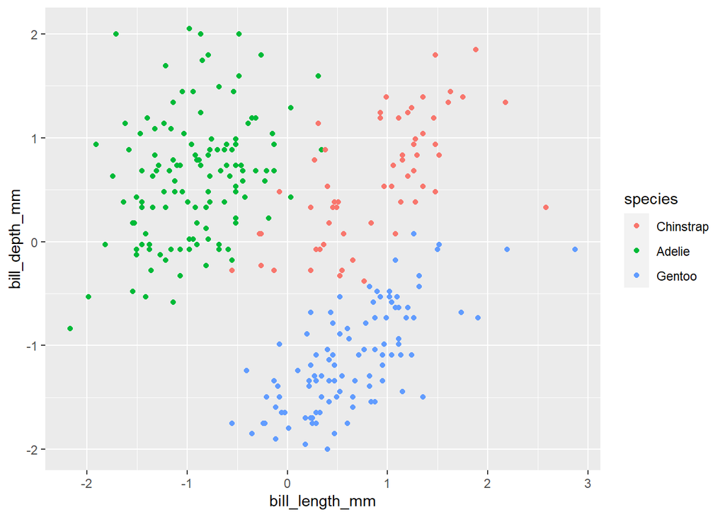

```r
ggplot(data=penguin_train,
mapping=aes(x=bill_length_mm, y=bill_depth_mm, color=species) ) +
geom_point()
```

- modify the plot to niclude the points from the test dataset.

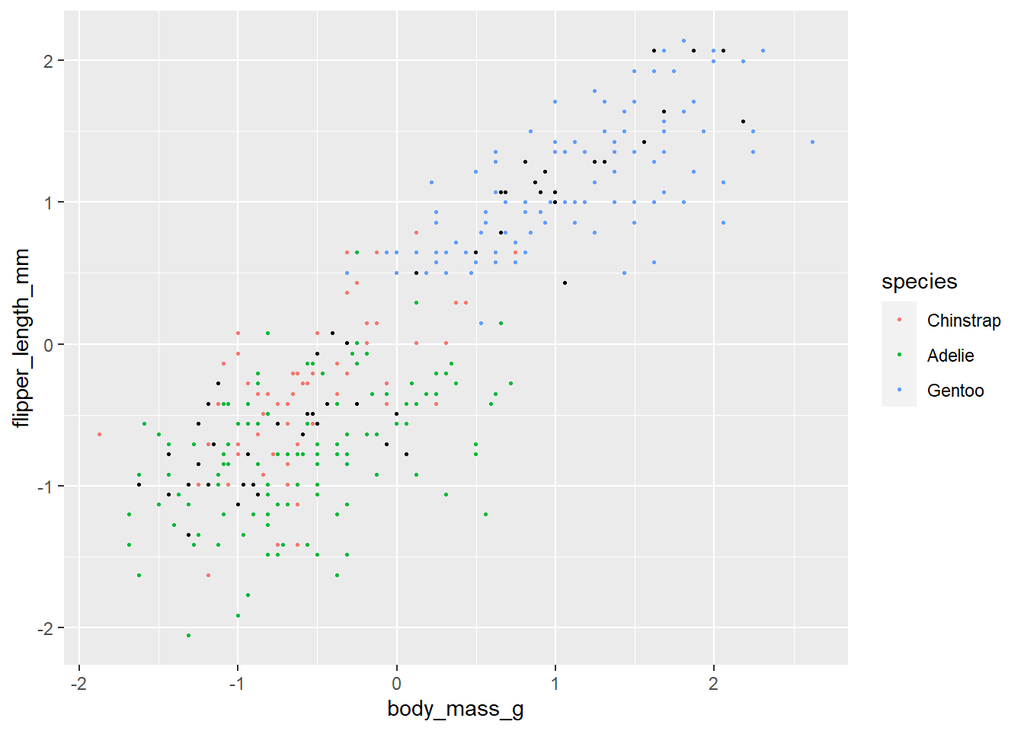

```r
ggplot( ) +
geom_point(data=penguin_train,
mapping=aes(x=body_mass_g, y=flipper_length_mm, color=species),
size=0.5) +
geom_point(data=penguin_test,
mapping=aes(x=body_mass_g, y=flipper_length_mm),
size=0.5)
```

- by refering to the example code above construct X_train Y_train X_test

```r
X_train = select(penguin_train, body_mass_g, flipper_length_mm)
Y_train = penguin_train$species
X_test = select(penguin_test, body_mass_g, flipper_length_mm)
```

- use the knn() function to create predictions setting K to 5 and store the output as Y_test

```r
# when breaking the KNN prediction chooses classification
# using random number so set seed for reproducibilty
set.seed(100)
# note as in general people will set use different seeds
# your results may differ to mine
# make predictions
Y_test_pred <- knn(X_train, X_test, Y_train, k=5)
```

- write the predictions Y_test into the penguin_test dataframe as species_predicted

```r
penguin_test$species_predicted <- Y_test_pred
```

- create a confusion table. Check you can interpret it by answering the following questions

```r
table(actual = penguin_test$species_actual,
predicted = penguin_test$species_predicted)
```

```
           predicted
actual      Chinstrap Adelie Gentoo
  Chinstrap         6      3      0
  Adelie            3     18      1
  Gentoo            0      0     19
```

- How many penguins in the test dataset were predicted as Adelie?
  - This corresponds to column 2 in the table above.
  - 3 + 18 = 21 were predicted Adelie (18 of these were actually Adelie and 3 were Chinstrap).
- How many penguins in the test dataset were actually Adelie?
  - This corresponds to row 2 in the table above.
  - 3 + 18 + 1 = 22 penguins in the test data were actually Adelie (using the info in the new column).
- How many penguins in the test dataset were correctly predicted Gentoo?
  - This corresponds to the bottom right diagonal value.
  - 19 penguins that were predicted Gentoo and were actually Gentoo.
- How many penguins in the test dataset were incorrectly predicted Gentoo?
  - The penguins predicted Gentoo are shown in column 3.
    - We see as well as the 19 correctly predicted Gentoo,1 predicted Gentoo was actually Adelie.
- How many penguins in the test dataset were actually Chinstrap but predicted to be Adelie?
  - 3 penguins were actually Chinstrap but predicted as Adelie.
- Calculate the number of correct predictions, and the overall accuracy.
  - Correct predictions are the diagonal elements. 6 + 18 + 19 = 43 correctly predicted penguins (out of 50). Hence overall accuracy is 43/50 = 0.86 or 86%.

```r
n = nrow(penguin_test)
n_correct <- sum(penguin_test$species_predicted == penguin_test$species_actual)
accuracy <- n_correct / n
n_correc
```

[output not shown]

```r
n = nrow(penguin_test)
n_correct <- sum(penguin_test$species_predicted == penguin_test$species_actual)
accuracy <- n_correct / n
n_correct
```

```
[1] 43
```

- Repeat the knn() analysis with K=5 but including the bill_depth_mm and bill_length_mm as input variables. Does this increase the accuracy of the method?

```r
X_train = select(penguin_train,
body_mass_g,
flipper_length_mm,
bill_depth_mm,
bill_length_mm)
Y_train = penguin_train$species
X_test = select(penguin_test,
body_mass_g,
flipper_length_mm,
bill_depth_mm,
bill_length_mm)
Y_test_pred_5 <- knn(X_train, X_test, Y_train, k=5)
penguin_test$species_pred_5 <- Y_test_pred_5
n <- nrow(penguin_test)
acc_5 <- sum(penguin_test$species_pred_5 == penguin_test$species_actual) / n
acc_5
```

```
[1] 1
```

- Previously the accuracy was 86% so including the bill measurements improved this to 100%.
- Edit your code to test how the accuracy changes when K takes values: 1, 5, 10, 15, 25, 50.

```r
# repeat the code using the k values given
Y_test_pred_1 <- knn(X_train, X_test, Y_train, k=1)
Y_test_pred_5 <- knn(X_train, X_test, Y_train, k=5)
Y_test_pred_10 <- knn(X_train, X_test, Y_train, k=10)
Y_test_pred_15 <- knn(X_train, X_test, Y_train, k=15)
Y_test_pred_25 <- knn(X_train, X_test, Y_train, k=25)
Y_test_pred_50 <- knn(X_train, X_test, Y_train, k=100)
penguin_test$species_pred_1 <- Y_test_pred_1
penguin_test$species_pred_5 <- Y_test_pred_5
penguin_test$species_pred_10 <- Y_test_pred_10
penguin_test$species_pred_15 <- Y_test_pred_15
penguin_test$species_pred_25 <- Y_test_pred_25
penguin_test$species_pred_50 <- Y_test_pred_50
# count number of penguins in test needed to calc % accuracy
n <- nrow(penguin_test)
# calculate accuracy
acc_1 <- sum(penguin_test$species_pred_1 == penguin_test$species_actual) / n
acc_5 <- sum(penguin_test$species_pred_5 == penguin_test$species_actual) / n
acc_10 <- sum(penguin_test$species_pred_10 == penguin_test$species_actual) / n
acc_15 <- sum(penguin_test$species_pred_15 == penguin_test$species_actual) / n
acc_25 <- sum(penguin_test$species_pred_25 == penguin_test$species_actual) / n
acc_50 <- sum(penguin_test$species_pred_50 == penguin_test$species_actual) / n
# store results into a dataframe to display as a table
k_vals <- c(1, 5, 10, 15, 25, 50)
acc_vals <- c(acc_1,acc_5,acc_10,acc_15,acc_25,acc_50)
results <- data.frame(k_vals, acc_vals)
results
```

[output not shown]

## The normal distribution and the Central Limit Theorem

### The Normal Distribution

When we look at the distribution of measurements we often compare it to the normal distribution (also called a Gaussian distribution).

R can calculate the normal distribution using function dnorm. The `stat_function` command lets us draw this in ggplot. The code below plots a normal distribution with mean 175cm and standard deviation 5cm.

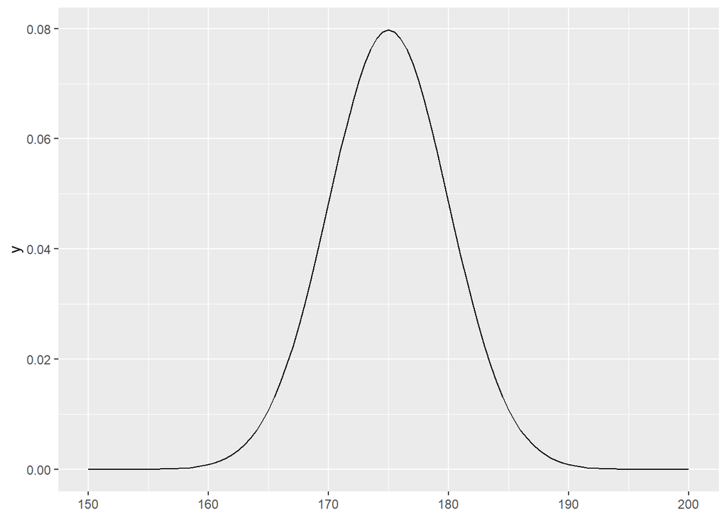

```r
ggplot() +
  xlim(150,200) +
  stat_function(fun = dnorm,
                args = list(mean = 175,
                            sd = 5))
```

Here the mean is a measure of where the distribution is centered (the average value) and standard deviation is a measure of the width of the distribution.

The second distribution in red added below has mean 160cm and standard deviation 2cm:

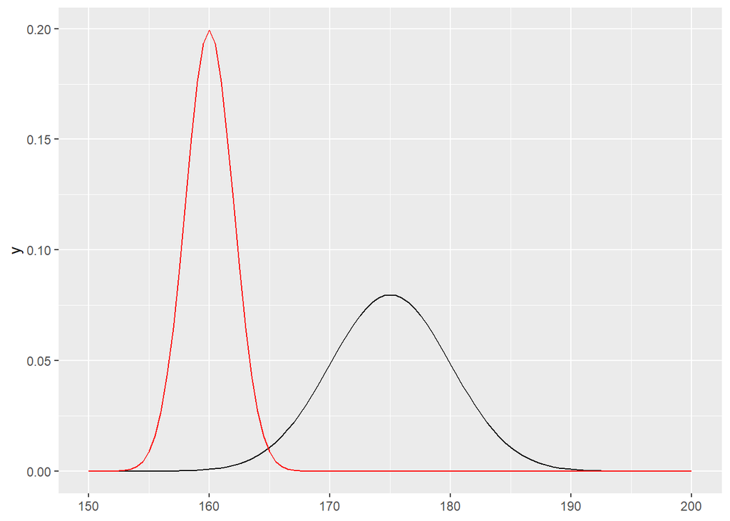

```r
ggplot() +
  xlim(150,200) +
  stat_function(fun = dnorm,
                args = list(mean = 175,
                            sd = 5)) +
  stat_function(fun = dnorm,
                args = list(mean = 160,
                            sd = 2),
                colour = "red")
```

It can be useful sometimes to generate random values drawn from a particular distribution. We can do this with the rnorm function.

```r
# generate a vector of 1000 values from
# a normal distribution with mean 175
# and standard deviation 5
heights <-  rnorm(1000, mean=175, sd=5)

# check contents
length(heights)
```

```
[1] 1000
```

```r
mean(heights)
```

```
[1] 175.1576
```

```r
sd(heights)
```

```
[1] 5.019825
```

You’ll notice that the mean and standard deviation of the data generated is not exactly 175 and 5. This is because the data is generated randomly, (e.g. if we flip a fair coin 1000 times we wouldn’t expect exactly 500 to be heads).

In line with this each time you run and generate a different dataset, you will get a slightly different result for the mean and standard deviation. However the values will always be “close” to those for underlying distribution from which we have generated the data.

Let’s view the distribution we have generated. We’ll start by storing it in a dataframe:

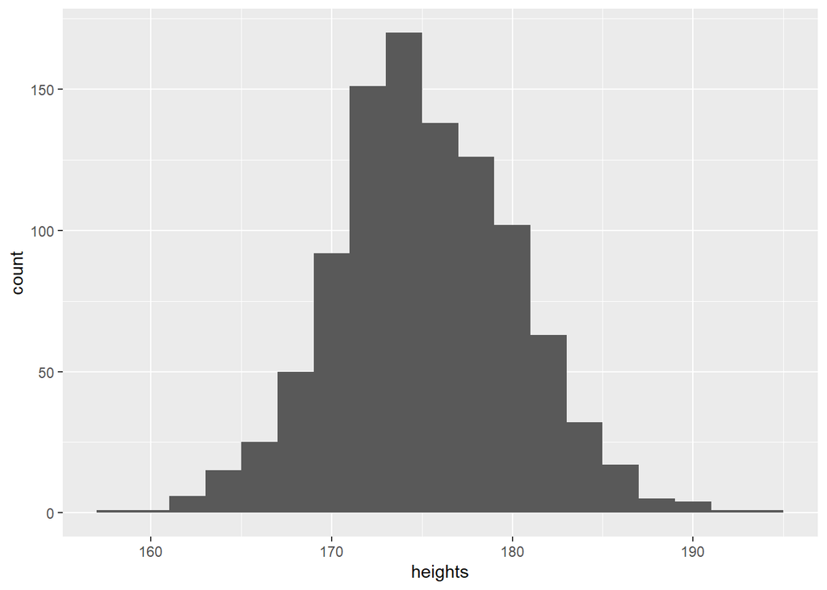

```r
# store our heights vector in a tidyverse data frame
# (a.k.a. tibble) makes it easier to use in ggplot
df <- tibble(heights)

ggplot(data = df) +
  geom_histogram(mapping = aes(x=heights),
                 binwidth = 2)
```

By eye its hard to tell if this is a normal distribution or not. One way to compare is to overlay our original function – the density for the corresponding normal distribution.

To compare we need to normalise the histogram area using the additional plot aesthetic `y=..density..`:

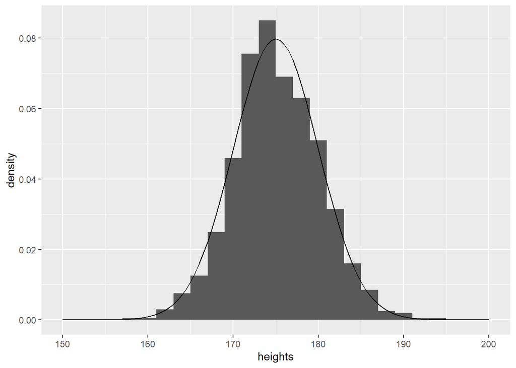

```r
ggplot(data = df) +
  geom_histogram(mapping = aes(x=heights,
                               y=..density..),
                 binwidth = 2) +
  geom_function(fun = dnorm,
                args = list(mean = 175,
                            sd = 5)) +
  xlim(150,200)
```

### Population sampling

In general when we look at a dataset we often deal with a sample of a population, rather than being able to measure the whole population.

In the above code we could imagine the 1000 data points represent 1000 measured heights from a population of males that has a population mean of 175cm.

```r
set.seed(100)

# generate a vector of 20 values taken from
# a population with mean 175 and stdev 5
sample_heights_20 <- rnorm(20, mean=175, sd=5)
```

In the code above we use the set.seed() command to fix the set of random numbers used. The numbers generated will still be random, but it means the same random numbers are used each time, and the values won’t change each time we rerun code. (This is useful for reproducible results).

Let’s assume we want to estimate the mean of the population using our sample. Our best guess at the population mean will be the mean of our sampled measurements:

```r
mean(sample_heights_20)
```

```
[1] 175.5393
```

In this case our estimate is 0.54cm different to the true population mean. One way to improve the estimate would be to take a bigger sample:

```r
set.seed(100)

sample_heights_1000 <- rnorm(1000, mean=175, sd=5)

mean(sample_heights_1000)
```

```
[1] 175.084
```

In our simulation taking 1000 measurements the mean of our larger sample is much closer to the true population mean (only 0.08cm out).

In general this rule holds - the larger the sample, the more representative the summary statistics will be of the population. What would be useful to us as data scientists would be to be able to quantify this effect. Handily we can do this using the central limit theorem (CLT).

## The Central Limit Theorem

This means as sample size $n$ increases the distribution of the calculated mean values for samples gets narrower and values are expected to lie closer to the true population mean.

```r
sample_means_25 <- replicate(1000, mean(rnorm(25,mean=175,sd=5) ) )
sample_means_100 <- replicate(1000, mean(rnorm(100,mean=175,sd=5) ) )
sample_means_400 <- replicate(1000, mean(rnorm(400,mean=175,sd=5) ) )
```

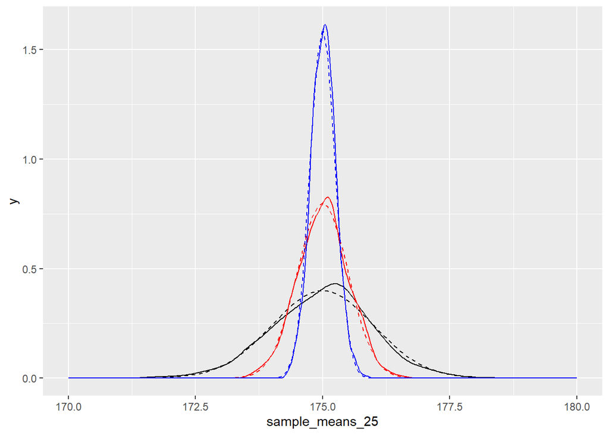

```r
ggplot() +
  geom_density(mapping = aes(x=sample_means_25)) +
  geom_function(fun = dnorm,args=list(mean=175,sd=5/sqrt(25)),linetype=2) +
  geom_density(mapping = aes(x=sample_means_100), color="red") +
  geom_function(fun = dnorm,args=list(mean=175,sd=5/sqrt(100)),linetype=2,color="red") +
  geom_density(mapping = aes(x=sample_means_400), color="blue") +
  geom_function(fun = dnorm,args=list(mean=175,sd=5/sqrt(400)),linetype=2,color="blue") +
  xlim(170,180)
```

Importantly this results holds for any distribution. Even if the population is not normal than for large samples (approx $n$>30) the distribution of the sample mean is approximately normal.

The following generates a random population of heights with a non-normal distribution:

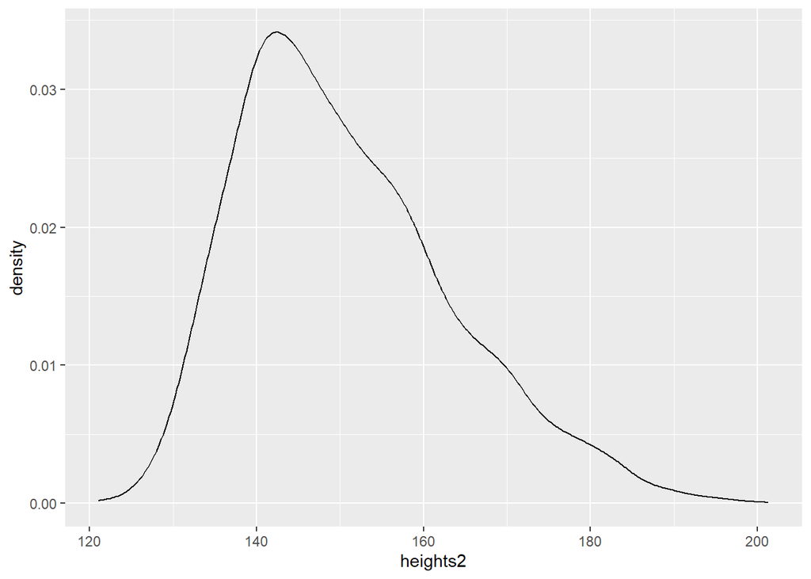

```r
heights2 <- 40*((4-0.25*rnorm(5435,mean=105,sd=5)/(5+rexp(5435,rate = 1)))/2+4)

ggplot() +
  geom_density(mapping = aes(x=heights2))
```

We can generate a sample from a vector of measurements in R using the `sample` function. For example, the following expression samples 10 values from the population.

```r
sample(heights2, 10)
```

```
 [1] 142.9775 171.2320 138.1396 165.7411 147.3892 152.2370 137.7606 144.8362
 [9] 168.4596 139.1332
```

and the following expression calculates the mean of 100 randomly sampled values.

```r
mean(sample(heights2, 100))
```

```
[1] 150.9772
```

Therefore we can replicate 1000 samples and plot the distribution of means as we did above:

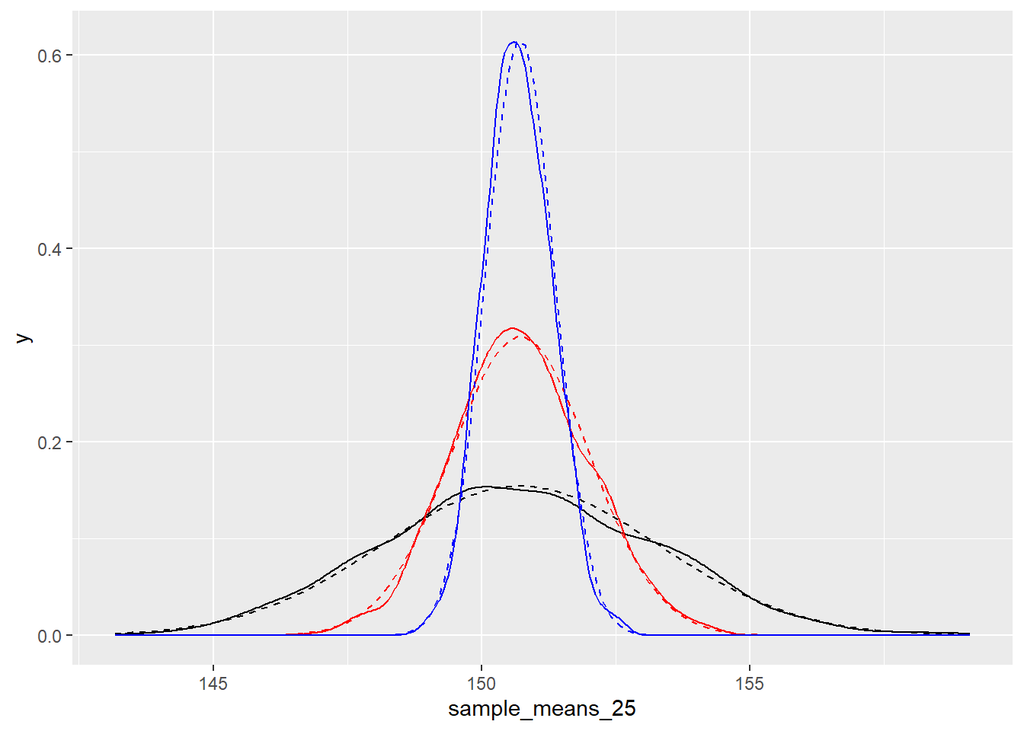

```r
sample_means_25 <- replicate(1000, mean(sample(heights2, 25) ) )
sample_means_100 <- replicate(1000, mean(sample(heights2, 100) ) )
sample_means_400 <- replicate(1000, mean(sample(heights2, 400) ) )

mu <- mean(heights2)
sigma <- sd(heights2)

ggplot() +
  geom_density(mapping = aes(x=sample_means_25)) +
  geom_function(fun = dnorm,args=list(mean=mu,sd=sigma/sqrt(25)),linetype=2) +
  geom_density(mapping = aes(x=sample_means_100), color="red") +
  geom_function(fun = dnorm,args=list(mean=mu,sd=sigma/sqrt(100)),linetype=2,color="red") +
  geom_density(mapping = aes(x=sample_means_400), color="blue") +
  geom_function(fun = dnorm,args=list(mean=mu,sd=sigma/sqrt(400)),linetype=2,color="blue")
```

We can see that for the sample mean distributions of n=100 and n=400 the distributions are symmetrical and look approximately normal.

This is a very useful result, because if we calculate the mean of a sample taken from a population we can then infer how close it will be to the true population mean. This is the foundation to hypothesis testing for difference in means and the t-test to test for statistical significance.